# RQ1 Step 2: Exploratory data analysis

What drives the real cost per m² of new houses across districts?

while True: learn(), Group 8, STAT462

2026-11-07

```r
source(file.path(proj_root, "R", "utils_data.R"))
library(knitr)

rq1   <- readRDS(file.path(paths$processed, "rq1_model_data.rds"))        # modelled rows (>= 5 houses)
full  <- read_csv(file.path(paths$processed, "rq1_district_quarter_full.csv"),
                  show_col_types = FALSE)                                   # all 9,715 rows
train <- rq1 |> filter(split == "train")

# the numeric candidate predictors (lags are looked at separately in section 8)
feat_num <- c("avg_house_m2", "rel_house_m2", "log_houses_n", "multiunit_share", "apt_share",
              "retire_share", "dwell_per_1000", "houses_yoy", "log_resid_alt_real",
              "log_nonres_real", "t_index")

dim(rq1); dim(train)
```

```
## [1] 8662   43
```

```
## [1] 7051   43
```

# 1 Purpose and ground rules

Step 1 produced a clean table. Before fitting models, EDA answers four questions:

1. **How does the response behave** over time and across places?
2. **Which candidate drivers are related to it**, and is the relationship real or a side-effect of something else?
3. **Which predictors overlap** with each other (a problem for interpreting linear regression)?
4. **What should Step 3 do** about the response, missing values and the feature set?

**Ground rule: explore the training set only (1990–2019).** Anything we *decide* after looking at the test years (2020–2026) would leak test information into the model, and the test score would no longer be an honest check. The one exception is section 7, which looks only at whether the two periods *differ*, so we can plan for that. It doesn’t choose features or settings from the test data.

# 2 Overview of the candidate predictors

```r
feature_summary <- train |>
  select(all_of(feat_num), real_cost_m2, log_real_cost_m2, rel_log_cost_m2) |>
  pivot_longer(everything(), names_to = "variable") |>
  group_by(variable) |>
  summarise(missing = sum(is.na(value)),
            min = min(value, na.rm = TRUE),
            median = median(value, na.rm = TRUE),
            mean = mean(value, na.rm = TRUE),
            max = max(value, na.rm = TRUE), .groups = "drop")
save_tab(feature_summary, "t04_feature_summary") |> kable(digits = 3, caption = "Training rows")
```

Training rows

| variable | missing | min | median | mean | max |
| --- | --- | --- | --- | --- | --- |
| apt_share | 0 | 0.000 | 0.000 | 0.024 | 0.819 |
| avg_house_m2 | 0 | 55.800 | 193.242 | 191.108 | 442.750 |
| dwell_per_1000 | 1355 | 0.300 | 4.500 | 5.822 | 48.700 |
| houses_yoy | 238 | -1.861 | 0.038 | 0.048 | 2.398 |
| log_houses_n | 0 | 1.609 | 3.466 | 3.492 | 7.649 |
| log_nonres_real | 0 | 0.000 | 15.366 | 15.358 | 20.647 |
| log_real_cost_m2 | 0 | 6.644 | 7.912 | 7.907 | 8.574 |
| log_resid_alt_real | 0 | 11.310 | 15.386 | 15.380 | 19.721 |
| multiunit_share | 0 | 0.000 | 0.083 | 0.135 | 0.878 |
| real_cost_m2 | 0 | 768.268 | 2729.935 | 2740.594 | 5290.754 |
| rel_house_m2 | 0 | -1.135 | -0.033 | -0.048 | 0.783 |
| rel_log_cost_m2 | 0 | -1.180 | -0.044 | -0.042 | 0.566 |
| retire_share | 0 | 0.000 | 0.000 | 0.024 | 0.756 |
| t_index | 0 | 2.000 | 62.000 | 61.562 | 120.000 |

## 2.1 Missing values are structural, not random

```r
train |>
  summarise(rows = n(),
            dwell_per_1000_missing = sum(is.na(dwell_per_1000)),
            dwell_per_1000_missing_from_1996 = sum(is.na(dwell_per_1000) & year >= 1996),
            houses_yoy_missing = sum(is.na(houses_yoy)),
            houses_yoy_missing_from_1996 = sum(is.na(houses_yoy) & year >= 1996),
            rows_from_1996 = sum(year >= 1996)) |>
  pivot_longer(everything()) |> kable()
```

| name | value |
| --- | --- |
| rows | 7051 |
| dwell_per_1000_missing | 1355 |
| dwell_per_1000_missing_from_1996 | 0 |
| houses_yoy_missing | 238 |
| houses_yoy_missing_from_1996 | 0 |
| rows_from_1996 | 5696 |

**Observation.** Only two predictors have gaps, and both have a known cause:

- `dwell_per_1000` is missing for **every** row before 1996 (Stats NZ’s per-resident series starts then), and for none after.
- `houses_yoy` needs the same quarter a year earlier, so it is missing in 1990–91.

**Decision for Step 3:** train on **1996Q1–2019Q4**. Then every row has every predictor, with no imputation. It costs 1355 training rows but still leaves 5,696. (Dropping `dwell_per_1000` instead would keep 1990–95, but section 5 shows it is one of the more useful predictors.)

# 3 Time: the national cycle

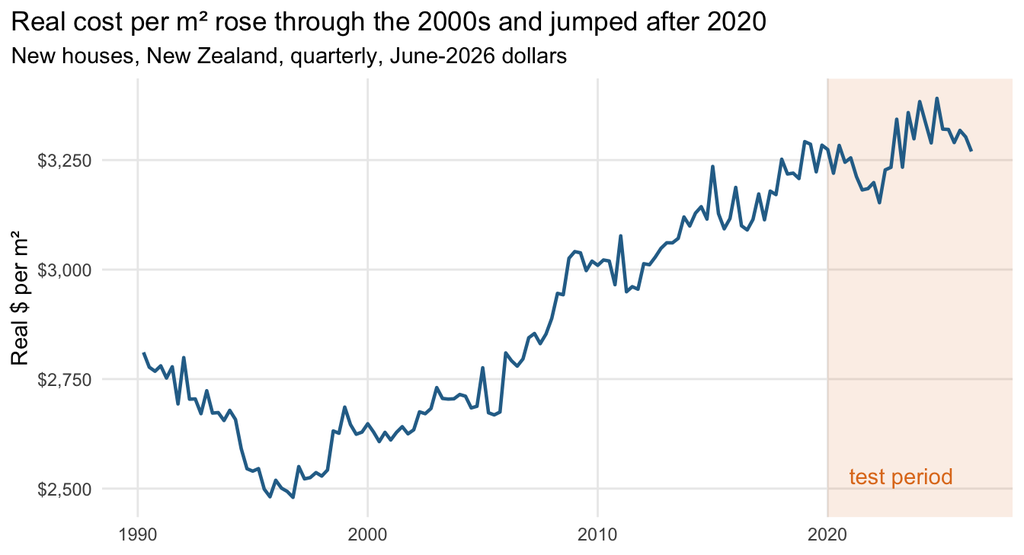

```r
nat_q <- full |>
  group_by(year, quarter, yq, split) |>
  summarise(real = sum(houses_val * real_factor) / sum(houses_m2), .groups = "drop") |>
  mutate(date = year + (quarter - 1) / 4)

p_time <- ggplot(nat_q, aes(date, real)) +
  annotate("rect", xmin = 2020, xmax = Inf, ymin = -Inf, ymax = Inf, alpha = 0.12, fill = "#e07a1f") +
  annotate("text", x = 2023.2, y = min(nat_q$real) + 50, label = "test period", colour = "#e07a1f") +
  geom_line(colour = "#2a6f97", linewidth = 0.8) +
  scale_y_continuous(labels = scales::label_dollar(accuracy = 1)) +
  labs(title = "Real cost per m² rose through the 2000s and jumped after 2020",
       subtitle = "New houses, New Zealand, quarterly, June-2026 dollars",
       x = NULL, y = "Real $ per m²")
save_fig(p_time, "fig06_nz_quarterly_trend")
```

```r
train |> group_by(quarter) |>
  summarise(median_real = median(real_cost_m2), median_relative = median(rel_log_cost_m2)) |>
  kable(digits = 3, caption = "By calendar quarter (training rows)")
```

By calendar quarter (training rows)

| quarter | median_real | median_relative |
| --- | --- | --- |
| 1 | 2744.507 | -0.045 |
| 2 | 2729.218 | -0.045 |
| 3 | 2730.082 | -0.039 |
| 4 | 2719.294 | -0.046 |

**Observation.** The national real cost moves in long waves (a dip in the early 1990s, a rise from about 1996 to 2009, another from 2012 to 2019, and a sharp step after 2020). There is **no seasonality**: medians by calendar quarter differ by less than 1%. So `quarter` is unlikely to help any model.

# 4 Place vs time: how much does each explain?

A simple way to measure how much a grouping “explains” is the R² of a regression of the response on that grouping alone: the share of the variance accounted for by group averages.

```r
r2 <- function(response, grouping) {
  f <- as.formula(paste(response, "~", grouping))
  summary(lm(f, data = train))$r.squared
}
groupings <- c("ta", "region", "island", "is_city", "factor(yq)", "factor(quarter)", "ta + factor(yq)")
labels    <- c("District", "Region", "Island", "City vs district", "Quarter (time)", "Season", "District + time")

var_expl <- tibble(grouping = labels,
                   `log real $/m²` = map_dbl(groupings, ~ r2("log_real_cost_m2", .x)),
                   `relative cost` = map_dbl(groupings, ~ r2("rel_log_cost_m2", .x)))
save_tab(var_expl, "t05_variance_explained") |> kable(digits = 3, caption = "R² of each grouping alone (training rows)")
```

R² of each grouping alone (training rows)

| grouping | log real $/m² | relative cost |
| --- | --- | --- |
| District | 0.193 | 0.318 |
| Region | 0.062 | 0.105 |
| Island | 0.002 | 0.003 |
| City vs district | 0.025 | 0.045 |
| Quarter (time) | 0.411 | 0.032 |
| Season | 0.000 | 0.000 |
| District + time | 0.604 | 0.352 |

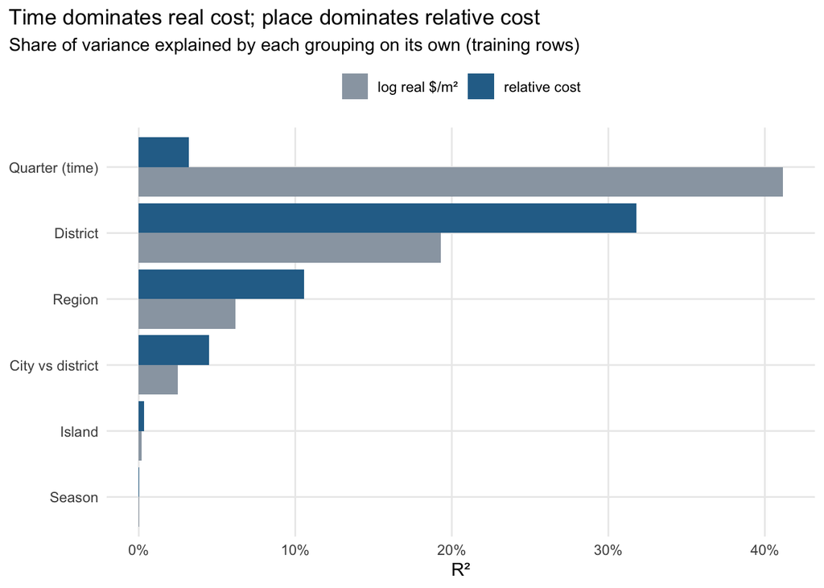

```r
p_var <- var_expl |>
  filter(grouping != "District + time") |>
  pivot_longer(-grouping, names_to = "response", values_to = "r2") |>
  mutate(grouping = fct_reorder(grouping, r2, .fun = max)) |>
  ggplot(aes(r2, grouping, fill = response)) +
  geom_col(position = "dodge") +
  scale_fill_manual(values = c("#9aa5b1", "#2a6f97")) +
  scale_x_continuous(labels = scales::percent) +
  labs(title = "Time dominates real cost; place dominates relative cost",
       subtitle = "Share of variance explained by each grouping on its own (training rows)",
       x = "R²", y = NULL, fill = NULL) +
  theme(legend.position = "top")
save_fig(p_var, "fig07_variance_explained", height = 3.6)
```

**Observation.**

- For **log real $/m²**, *time* (which quarter) explains about 41% of the variance and *district* about 19%; together about 60%. Most of the variation is the whole country moving together.
- For **relative cost**, time explains almost nothing (by construction) and district explains 32%. This is the cross-district signal RQ1 is about.
- Region explains far less than district, and island almost nothing, so cost differences are **local**, not broad North-vs-South patterns. Season explains nothing.

# 5 Which districts are dear or cheap?

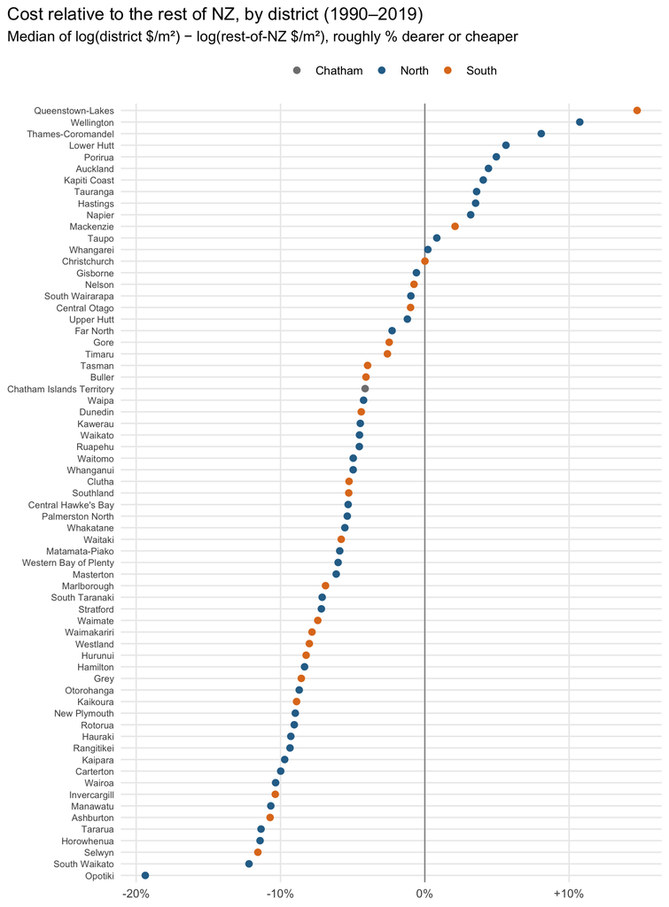

```r
district_rank <- train |>
  group_by(ta, island) |>
  summarise(median_rel = median(rel_log_cost_m2), quarters = n(), .groups = "drop") |>
  mutate(ta = fct_reorder(str_remove(ta, " District| City"), median_rel))

p_rank <- ggplot(district_rank, aes(median_rel, ta, colour = island)) +
  geom_vline(xintercept = 0, colour = "grey60") +
  geom_point(size = 2) +
  scale_colour_manual(values = c(North = "#2a6f97", South = "#e07a1f", Chatham = "grey50")) +
  scale_x_continuous(labels = function(x) paste0(ifelse(x > 0, "+", ""), round(100 * x), "%")) +
  labs(title = "Cost relative to the rest of NZ, by district (1990–2019)",
       subtitle = "Median of log(district $/m²) − log(rest-of-NZ $/m²), roughly % dearer or cheaper",
       x = NULL, y = NULL, colour = NULL) +
  theme(legend.position = "top", axis.text.y = element_text(size = 7))
save_fig(p_rank, "fig08_district_ranking", height = 9.5)
```

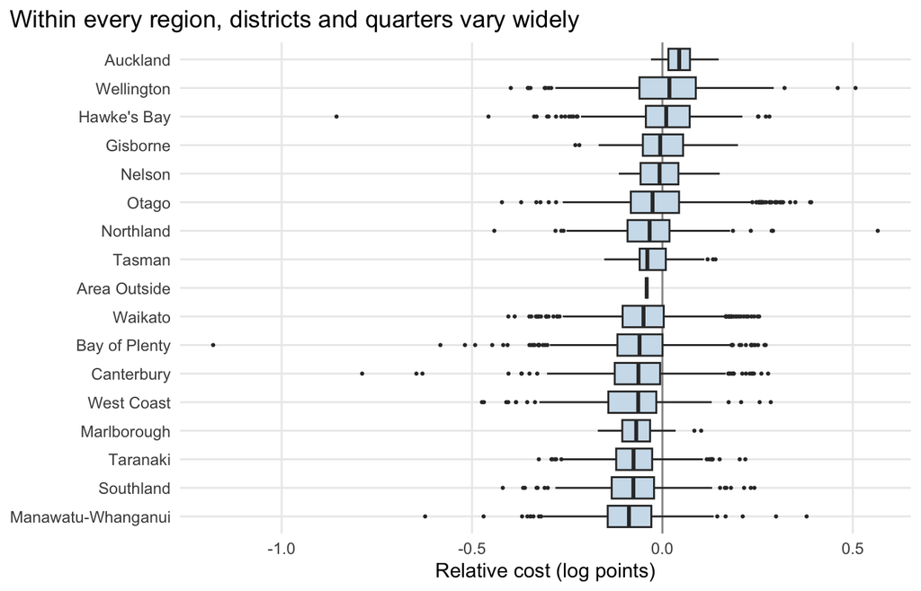

```r
p_region <- train |>
  mutate(region = fct_reorder(str_remove(region, " Region"), rel_log_cost_m2, .fun = median)) |>
  ggplot(aes(rel_log_cost_m2, region)) +
  geom_vline(xintercept = 0, colour = "grey60") +
  geom_boxplot(outlier.size = 0.4, fill = "#cfe0ec") +
  labs(title = "Within every region, districts and quarters vary widely",
       x = "Relative cost (log points)", y = NULL)
save_fig(p_region, "fig09_region_boxplot", height = 4.5)
```

**Observation.**

- **Dearest** (1990–2019): Queenstown-Lakes (about +15% vs the rest of NZ), Wellington City (+11%), Thames-Coromandel, Lower Hutt, Porirua and Auckland. These are high-amenity, holiday-home or land-constrained urban markets.
- **Cheapest:** Ōpōtiki (about −19%, a small district), South Waikato, Selwyn, Horowhenua, Tararua and Ashburton. These are rural districts, plus Selwyn, a large fast-growing subdivision market where volume builders put up many similar houses.
- **Why most districts sit below 0:** “the rest of NZ” is weighted by floor area, so it’s dominated by large and relatively dear Auckland, Wellington and Christchurch. A typical *small* district is therefore a few percent below it. The ordering, not the zero line, is what matters.
- The region boxes overlap heavily, so region alone is a weak guide, matching its low R² above.

# 6 Candidate drivers vs the response

## 6.1 A lesson in confounding: house size

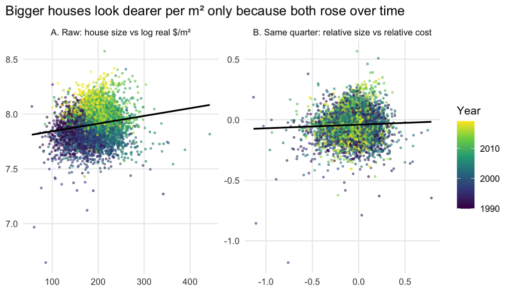

```r
p_size <- bind_rows(
  train |> transmute(panel = "A. Raw: house size vs log real $/m²",
                     x = avg_house_m2, y = log_real_cost_m2, year),
  train |> transmute(panel = "B. Same quarter: relative size vs relative cost",
                     x = rel_house_m2, y = rel_log_cost_m2, year)
) |>
  ggplot(aes(x, y)) +
  geom_point(aes(colour = year), size = 0.6, alpha = 0.5) +
  geom_smooth(method = "lm", colour = "black", se = FALSE, linewidth = 0.8) +
  scale_colour_viridis_c() +
  facet_wrap(~ panel, scales = "free") +
  labs(title = "Bigger houses look dearer per m² only because both rose over time",
       x = NULL, y = NULL, colour = "Year")
save_fig(p_size, "fig10_house_size_confounding", height = 4)
```

**Observation.** Panel A suggests bigger houses cost *more* per m². But colour shows why: houses grew from about 150 m² to over 200 m² between 1990 and the late 2000s *while* real costs also rose, so time drives both. Compare houses **in the same quarter** (panel B) and the relationship almost disappears (r = 0.05). Larger-than-average houses for their time are *not* clearly cheaper or dearer per m². We expected a negative slope (fixed costs spread over more m²); the data don’t show it, perhaps because bigger houses are also built to a higher spec, which cancels the effect out. A predictor that looks important can be standing in for something else. This is **confounding**, and it’s why the relative framing helps.

## 6.2 All numeric drivers

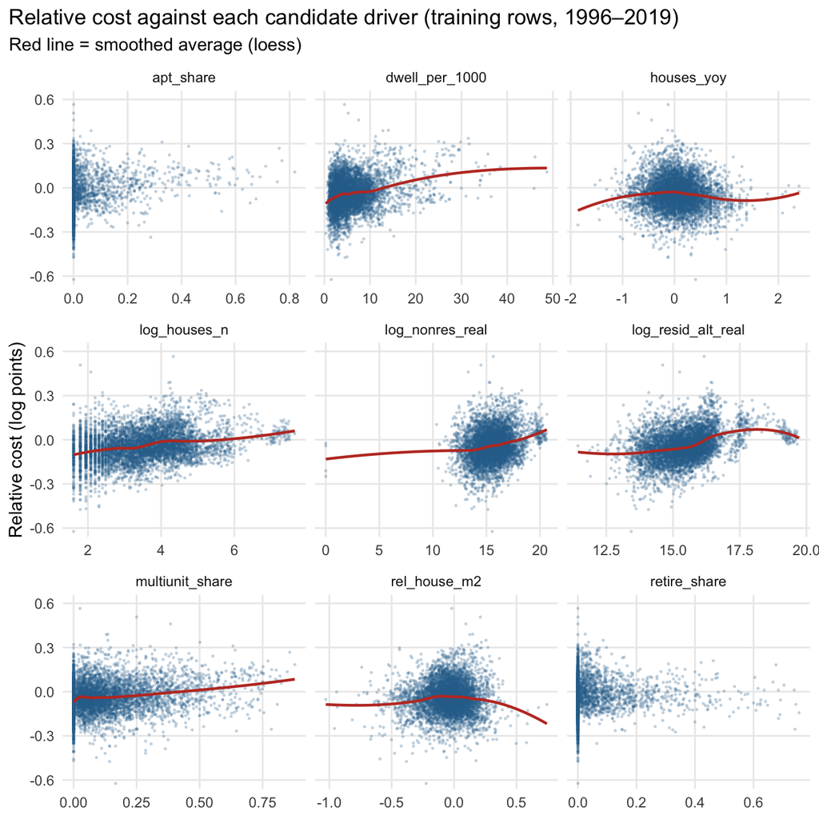

```r
p_feat <- train |>
  filter(year >= 1996) |>
  select(rel_log_cost_m2, all_of(setdiff(feat_num, c("t_index", "avg_house_m2")))) |>
  pivot_longer(-rel_log_cost_m2, names_to = "feature") |>
  ggplot(aes(value, rel_log_cost_m2)) +
  geom_point(size = 0.3, alpha = 0.2, colour = "#2a6f97") +
  geom_smooth(method = "loess", span = 0.5, colour = "#c0392b", se = FALSE, linewidth = 0.8) +
  facet_wrap(~ feature, scales = "free_x", ncol = 3) +
  coord_cartesian(ylim = c(-0.6, 0.6)) +
  labs(title = "Relative cost against each candidate driver (training rows, 1996–2019)",
       subtitle = "Red line = smoothed average (loess)",
       x = NULL, y = "Relative cost (log points)")
save_fig(p_feat, "fig11_features_vs_relative_cost", height = 7)
```

```r
cor_tab <- tibble(feature = feat_num) |>
  mutate(
    `with log real $/m²` = map_dbl(feature, ~ cor(train[[.x]], train$log_real_cost_m2, use = "complete.obs")),
    `with relative cost` = map_dbl(feature, ~ cor(train[[.x]], train$rel_log_cost_m2, use = "complete.obs"))
  ) |>
  arrange(desc(abs(`with relative cost`)))
save_tab(cor_tab, "t06_feature_correlations") |>
  kable(digits = 3, caption = "Pearson correlation with each response (training rows)")
```

Pearson correlation with each response (training rows)

| feature | with log real $/m² | with relative cost |
| --- | --- | --- |
| log_resid_alt_real | 0.281 | 0.353 |
| log_houses_n | 0.233 | 0.279 |
| dwell_per_1000 | 0.176 | 0.247 |
| log_nonres_real | 0.243 | 0.216 |
| multiunit_share | 0.141 | 0.202 |
| apt_share | 0.093 | 0.162 |
| houses_yoy | -0.066 | -0.070 |
| avg_house_m2 | 0.179 | 0.068 |
| retire_share | 0.132 | 0.064 |
| t_index | 0.554 | 0.054 |
| rel_house_m2 | 0.016 | 0.045 |

**Observation.**

- The strongest (still modest) links with relative cost are **building activity**: real value of residential alterations, number of new houses, building intensity per resident and non-residential activity. Busier, growing markets are dearer per m², which fits a story of competition for builders and higher-spec urban building.
- **Multi-unit share** is positively related: places building apartments and townhouses are denser and costlier.
- **House size**, once compared within the quarter, has almost no linear relationship. (Section 5.1; the forest in Step 3 can still check for a non-linear one.)
- **`houses_yoy`** (a sudden change in volume) is close to zero.
- `t_index` correlates strongly with *real* cost but not with *relative* cost, as expected.
- No single numeric driver is strong (|r| < 0.4). The models will have to combine several, and location will carry a lot of the signal.

# 7 Overlap between predictors (multicollinearity)

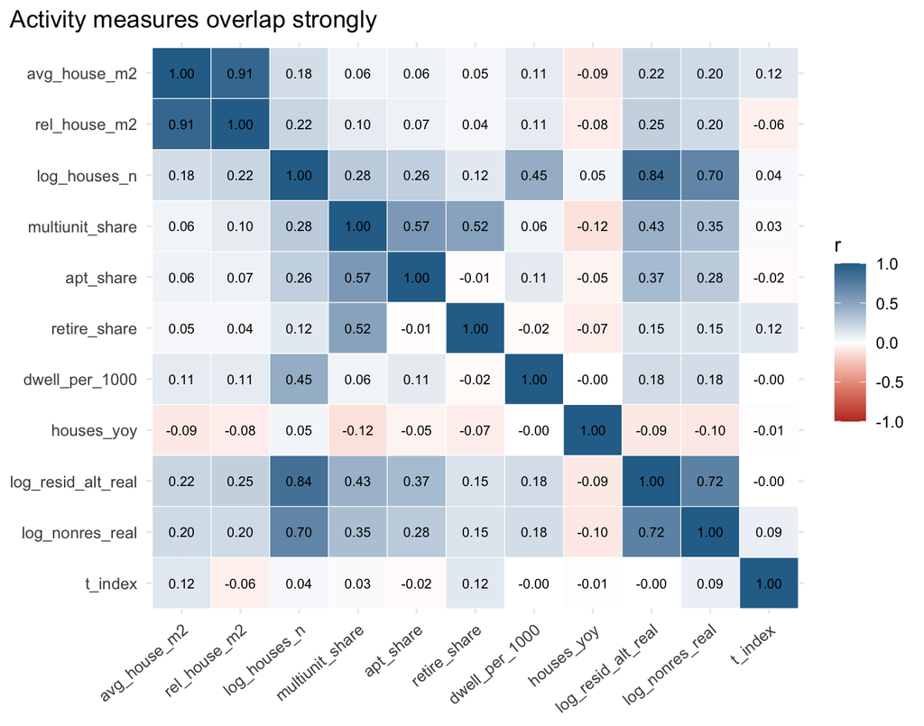

```r
cm <- cor(train |> filter(year >= 1996) |> select(all_of(feat_num)), use = "pairwise.complete.obs")
p_heat <- as_tibble(cm, rownames = "a") |>
  pivot_longer(-a, names_to = "b", values_to = "r") |>
  mutate(a = factor(a, levels = feat_num), b = factor(b, levels = rev(feat_num))) |>
  ggplot(aes(a, b, fill = r)) +
  geom_tile(colour = "white") +
  geom_text(aes(label = sprintf("%.2f", r)), size = 2.6) +
  scale_fill_gradient2(low = "#c0392b", mid = "white", high = "#2a6f97", limits = c(-1, 1)) +
  labs(title = "Activity measures overlap strongly", x = NULL, y = NULL, fill = "r") +
  theme(axis.text.x = element_text(angle = 40, hjust = 1))
save_fig(p_heat, "fig12_feature_correlation_heatmap", height = 5.5)
```

The **variance inflation factor (VIF)** measures how much a coefficient’s variance is inflated because that predictor can be predicted from the others: VIF = 1 / (1 − R²) from regressing it on all other predictors. Above about 5 is a warning, above 10 a problem.

```r
vif_data <- train |> filter(year >= 1996) |> select(all_of(feat_num)) |> drop_na()
vif_tab <- tibble(feature = feat_num) |>
  mutate(VIF = map_dbl(feature, function(v) {
    r2_v <- summary(lm(reformulate(setdiff(feat_num, v), response = v), data = vif_data))$r.squared
    1 / (1 - r2_v)
  })) |>
  arrange(desc(VIF))
save_tab(vif_tab, "t07_vif") |> kable(digits = 2)
```

| feature | VIF |
| --- | --- |
| avg_house_m2 | 7.63 |
| rel_house_m2 | 7.58 |
| log_houses_n | 6.25 |
| log_resid_alt_real | 5.56 |
| multiunit_share | 2.77 |
| log_nonres_real | 2.35 |
| apt_share | 1.89 |
| retire_share | 1.72 |
| dwell_per_1000 | 1.62 |
| t_index | 1.29 |
| houses_yoy | 1.11 |

**Observation.** Number of new houses, residential alterations and non-residential activity are all measures of *how big and busy* a district’s building market is, so they overlap (r ≈ 0.7–0.85). Raw and relative house size also overlap by construction. That’s fine for **prediction**, and **lasso** is designed to cope with it (it tends to keep one of a correlated group). But in plain **linear regression** the individual coefficients of overlapping predictors will be unstable and shouldn’t be over-interpreted. For Step 3 we will use `rel_house_m2` (not both size measures) in the relative model.

# 8 Train vs test: does the past look like the future?

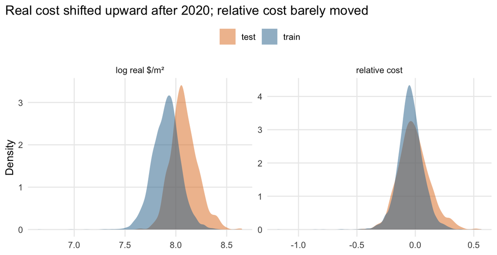

```r
p_shift <- rq1 |>
  select(split, `log real $/m²` = log_real_cost_m2, `relative cost` = rel_log_cost_m2) |>
  pivot_longer(-split) |>
  ggplot(aes(value, fill = split)) +
  geom_density(alpha = 0.5, colour = NA) +
  facet_wrap(~ name, scales = "free") +
  scale_fill_manual(values = c(train = "#2a6f97", test = "#e07a1f")) +
  labs(title = "Real cost shifted upward after 2020; relative cost barely moved",
       x = NULL, y = "Density", fill = NULL) +
  theme(legend.position = "top")
save_fig(p_shift, "fig13_train_test_shift", height = 3.6)
```

```r
rq1 |> group_by(split) |>
  summarise(median_real = median(real_cost_m2),
            mean_log_real = mean(log_real_cost_m2),
            mean_relative = mean(rel_log_cost_m2),
            sd_relative = sd(rel_log_cost_m2)) |>
  kable(digits = 3)
```

| split | median_real | mean_log_real | mean_relative | sd_relative |
| --- | --- | --- | --- | --- |
| test | 3198.377 | 8.082 | -0.011 | 0.133 |
| train | 2729.935 | 7.907 | -0.042 | 0.108 |

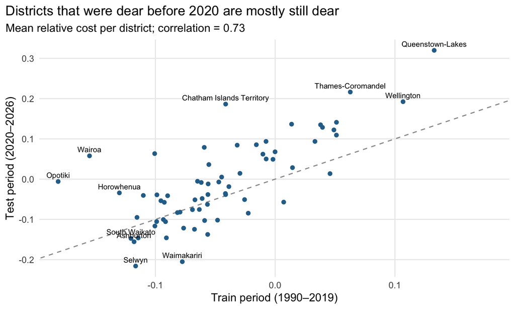

```r
persist <- rq1 |>
  group_by(ta, split) |>
  summarise(mean_rel = mean(rel_log_cost_m2), .groups = "drop") |>
  pivot_wider(names_from = split, values_from = mean_rel)

p_persist <- ggplot(persist, aes(train, test)) +
  geom_abline(slope = 1, intercept = 0, colour = "grey60", linetype = 2) +
  geom_point(colour = "#2a6f97") +
  geom_text(data = persist |> filter(abs(test) > 0.15 | abs(train) > 0.12),
            aes(label = str_remove(ta, " District| City")), size = 2.6, vjust = -0.7) +
  labs(title = "Districts that were dear before 2020 are mostly still dear",
       subtitle = paste0("Mean relative cost per district; correlation = ",
                         round(cor(persist$train, persist$test, use = "complete.obs"), 2)),
       x = "Train period (1990–2019)", y = "Test period (2020–2026)") +
  scale_x_continuous(expand = expansion(mult = c(0.05, 0.2)))
save_fig(p_persist, "fig14_district_persistence", height = 4.2)
```

**Observation.** The median real cost in the test period is about 17% higher than in training. This matters for model choice: **trees and random forests cannot extrapolate**. A tree predicts averages of training rows, so it can never predict a level above anything it saw before 2020. A linear model with a time trend *can* extrapolate, but only as a straight line. For the **relative** response the shift is small, and districts keep their rank (correlation 0.73), so the patterns learned before 2020 should transfer.

# 9 Lagged response

```r
train |>
  summarise(`lag 1 quarter` = cor(real_cost_m2_lag1, real_cost_m2, use = "complete.obs"),
            `lag 4 quarters` = cor(real_cost_m2_lag4, real_cost_m2, use = "complete.obs")) |>
  kable(digits = 3, caption = "Correlation of real $/m² with its own past values")
```

Correlation of real $/m² with its own past values

| lag 1 quarter | lag 4 quarters |
| --- | --- |
| 0.751 | 0.707 |

**Observation.** Last quarter’s cost is the single best predictor of this quarter’s (r = 0.75). But a model built on it answers *“what will cost be, given what it just was?”* (forecasting), not *“what drives cost?”* (explanation). It would also swamp every other driver in importance. **Decision:** the main models exclude lags; we may add a lagged model in Step 3 as a forecasting benchmark.

# 10 Summary: findings and decisions for Step 3

| # | Finding | Decision for Step 3 |
| --- | --- | --- |
| 1 | Time explains ~40% of variance in log real $/m²; district ~20%. Test years are ~17% dearer. | Fit **two responses**: *relative cost* (main, answers “across districts”) and *log real $/m²* (secondary, with a time trend). |
| 2 | Relative cost: district explains ~32%; rankings persist into 2020–26 (r ≈ 0.73). | Location will be the strongest driver. Include district (as categories) in some models and not in others, to see how much the measurable drivers explain on their own. |
| 3 | Region weak, island ~0, season ~0. | Keep region; drop island and season. |
| 4 | Activity measures (alterations, new houses, non-residential, per-1000) and multi-unit share relate positively to relative cost. | Core numeric predictors. |
| 5 | House size: confounded by time; almost no relationship within the quarter. | Use `rel_house_m2` with the relative response; `avg_house_m2` with the real response. |
| 6 | Activity measures overlap (VIF). | Interpret linear coefficients with care; rely on lasso and forest importance for “what drives”. |
| 7 | `dwell_per_1000` missing before 1996. | Train on **1996Q1–2019Q4** (no imputation). |
| 8 | Lags are strong but answer a forecasting question. | Exclude from the main models. |
| 9 | Trees can’t extrapolate the post-2020 level. | Expect trees/forests to do poorly on *real* cost in 2020–26 but fine on *relative* cost. Worth saying in the report. |

**Metrics for Step 3:** RMSE and MAE on the log scale (≈ % error), plus MAPE on $/m² for the real response, to keep the pitch’s metric. Baseline to beat: predicting each district’s training-period average.

# 11 Appendix: helper functions

This notebook uses helper functions from `R/utils_data.R`, printed here so the document is complete on its own.

```r
# =============================================================================
# R/utils_data.R
# Shared helpers for reading and reshaping Stats NZ data.
# Source this from any Rmd after the project root has been set:
#   source(file.path(proj_root, "R", "utils_data.R"))
# =============================================================================

suppressPackageStartupMessages({
  library(data.table)
  library(tidyverse)
})

# ---- Paths (all relative to the project root) -------------------------------
paths <- list(
  raw_extracted = "data/raw/extracted",
  raw_cgpi      = "data/raw/external/cgpi",
  reference     = "data/reference",
  processed     = "data/processed",
  fig_rq1       = "outputs/figures/rq1",
  tab_rq1       = "outputs/tables/rq1"
)

# ---- Reading Stats NZ "Infoshare" long-format CSVs --------------------------
# Every Infoshare file has one row per (series x period). We read only the
# columns that carry information and give them short working names.
#
# Notes
# * `Period` MUST be read as text: as a number, "2025.10" becomes 2025.1,
#   which is indistinguishable from January.
# * integer64 is turned off so that large dollar values come back as doubles
#   (integer64 silently overflows on division).
read_infoshare <- function(file,
                           dir = paths$raw_extracted,
                           keep_status = FALSE) {
  cols <- c("Series_reference", "Period", "Data_value",
            "Series_title_1", "Series_title_2",
            "Series_title_3", "Series_title_4", "Series_title_5")
  if (keep_status) cols <- c(cols, "Status")

  dt <- fread(file.path(dir, file),
              select      = cols,
              colClasses  = list(character = "Period"),
              integer64   = "double",
              na.strings  = c("", "NA"),
              showProgress = FALSE)

  as_tibble(dt) |>
    rename(series  = Series_reference,
           period  = Period,
           value   = Data_value,
           area    = Series_title_1,
           btype   = Series_title_2,
           work    = Series_title_3,
           measure = Series_title_4,
           adjust  = Series_title_5)   # Actual / Seasonally adjusted / Trend (regional files only)
}

# ---- Period helpers ----------------------------------------------------------
# "YYYY.MM" -> integer year / month / calendar quarter
period_year    <- function(p) as.integer(substr(p, 1, 4))
period_month   <- function(p) as.integer(substr(p, 6, 7))
month_quarter  <- function(m) (m - 1L) %/% 3L + 1L

# Label like "2019Q3"
yq_label <- function(year, quarter) paste0(year, "Q", quarter)

# Sequential quarter index (1990Q1 = 1) - handy as a numeric time trend
yq_index <- function(year, quarter) (year - 1990L) * 4L + quarter

# ---- GST ---------------------------------------------------------------------
# Consent values are GST-inclusive. GST was 12.5% from 1 Jul 1989 to
# 30 Sep 2010 and 15% from 1 Oct 2010. Every month in our data is >= 1990,
# so only these two rates apply. Quarter boundaries line up with the change
# (2010Q4 starts on 1 Oct 2010), so a quarter-level rule is exact.
gst_rate <- function(year, quarter) {
  if_else(yq_index(year, quarter) >= yq_index(2010L, 4L), 0.15, 0.125)
}

# ---- Small display helpers ---------------------------------------------------
fmt_int <- function(x) format(round(x), big.mark = ",", scientific = FALSE)
fmt_dol <- function(x) paste0("$", fmt_int(x))
fmt_pct <- function(x, d = 1) paste0(format(round(100 * x, d), nsmall = d), "%")

# ---- Figures -----------------------------------------------------------------
theme_set(theme_minimal(base_size = 11) +
            theme(plot.title.position = "plot",
                  panel.grid.minor = element_blank()))

# Save a ggplot as PNG (for the report) and return it (so it also shows in the Rmd)
save_fig <- function(p, name, dir = paths$fig_rq1, width = 7, height = 4.2) {
  dir.create(dir, recursive = TRUE, showWarnings = FALSE)
  ggsave(file.path(dir, paste0(name, ".png")), p,
         width = width, height = height, dpi = 200, bg = "white")
  p
}

# Save a table as CSV (for the report) and return it
save_tab <- function(df, name, dir = paths$tab_rq1) {
  dir.create(dir, recursive = TRUE, showWarnings = FALSE)
  write_csv(df, file.path(dir, paste0(name, ".csv")))
  df
}
```